# **Audit Level Report**

Generated: Oct 08 2020 18:56

# **Sample:** CBA.G4F-426-L3W

## Analysis Parameters

| Analytes | Transferrin, Alpha1 AntiTrypsin |
| --- | --- |
| Equipment Protocol | Vertical Tanks 1 |
| Analysis Protocol | V1.01 |
| Usage | Research Use Only |

## Summary

The analysis presented in this document resulted from following the biosignatures ‘Gel-As-Assay’ workflow. A hybrid 2D DiGE approach is used to increase automation, quality and reproducibility. The key difference is that a fixed standard is always used rather than a pooled standard.

2µL Human Plasma is labelled with Cy5 (or equivalent) and a fixed standard labelled with Cy3 following protocols defined by biosignatures. Images of the channels are then uploaded to a cloud analysis platform. The Cy3 standard is then aligned into a fixed reference space and automated QC procedures assess the fixed standard. If the standard passes the automated procedures a fixed feature pattern is applied and feature measures obtained. This report is then automatically generated detailing the results for a selected subset of analytes.

# **Analytes:**

**Overview**

The gel image below shows the locations of the analyte chains presented in this report.

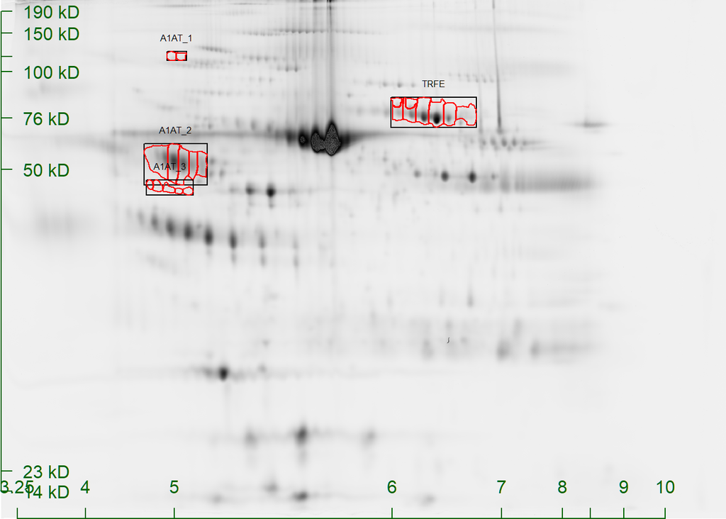

# Transferrin (P02787)

[From: Human plasma protein N-glycosylation](https://link.springer.com/article/10.1007/s10719-015-9626-2#Sec34)

> Serotransferrin (STF), also known as transferrin, ß1 metal binding globulin or siderophilin, is a 698 amino acid protein (19 amino acids of which are signal peptide) with a molecular mass of approximately 77 kDa (without glycosylation) [8, 337]. The protein consists of two globular domains, the N-lobe and the C-lobe which divided into two subdomains each (N1, N2, C1 and C2). The two main domains are connected by a short linker peptide [337–339]. The N-lobe is 336 amino acids in size and spans from Val25 to Glu347, while the C-lobe is 343 amino acids long and ranges from Val361 to Lys683 [337]. The lobes can interact to form a hydrophilic metal ion binding site [337]. STF is mostly produced by hepatocytes, although other tissues have also shown expression, albeit at significantly lower amounts [337]. The plasma concentration is highly stable from the age of 2 years on, with a range between 2 and 3 mg/mL [337, 340]. Levels may increase during pregnancy up to 5 mg/mL [141].

### CBA.G4F-426-L3W TRFE

**Replicate 1 : 50014_Cy5 450_Cy3 455 Cy5.gel_sc.gel**

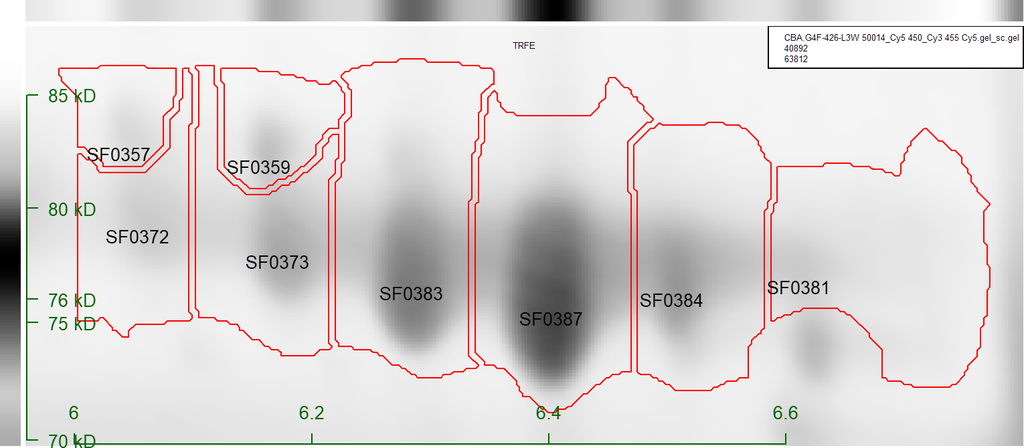

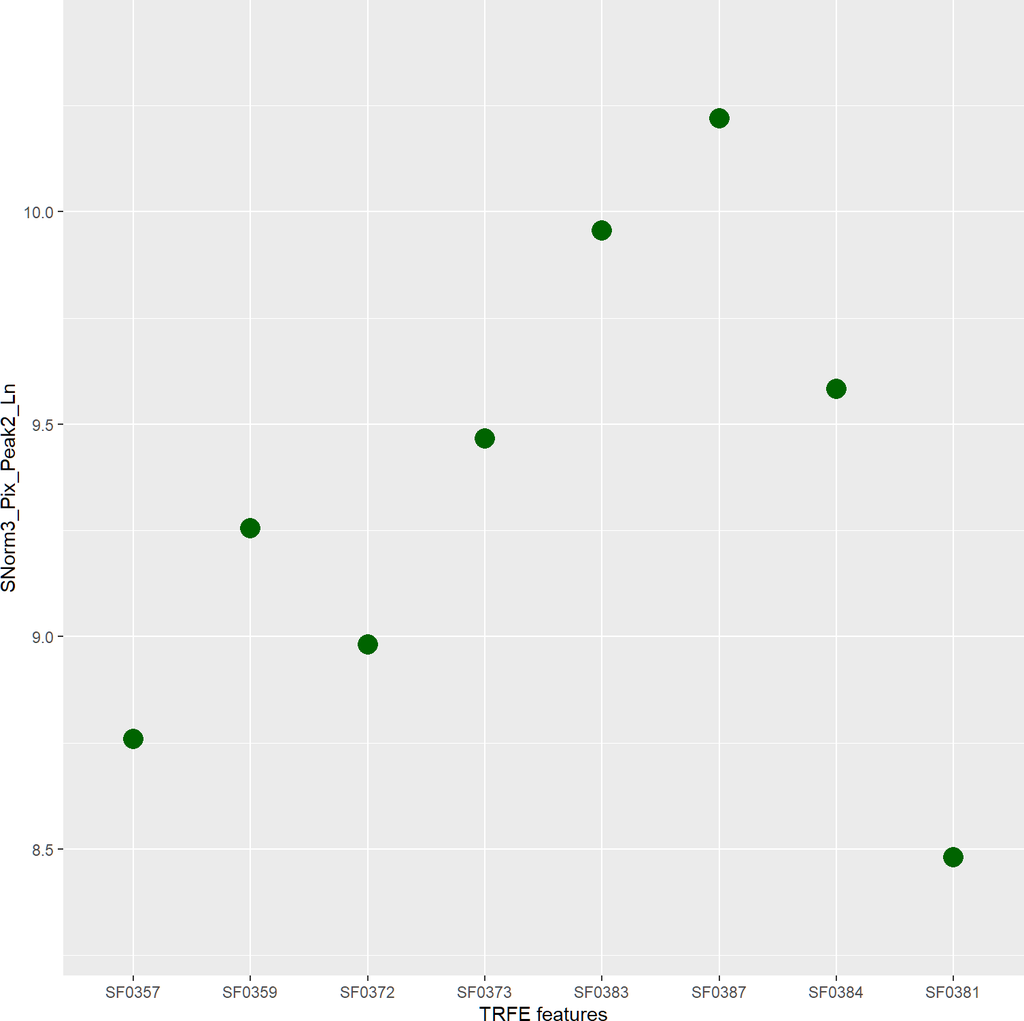

**Replicate 2 : 72288_Cy5 440_Cy3 455 Cy5.gel_sc.gel**

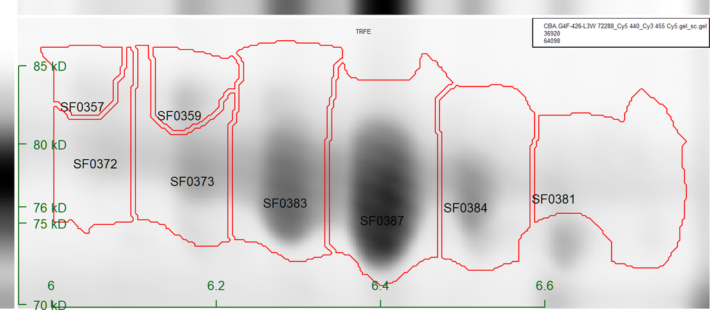

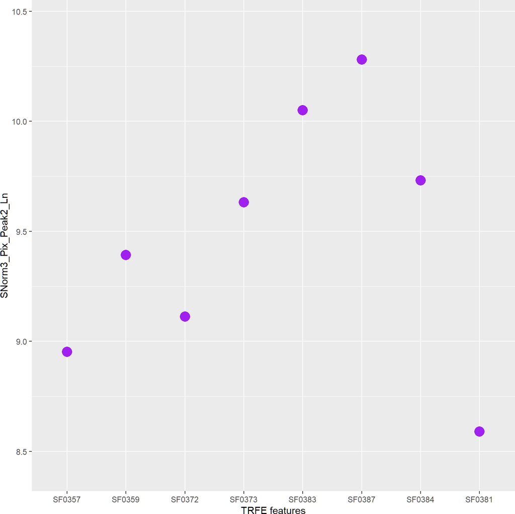

**Replicate 3 : 78543_Cy5 440_Cy3 445 Cy5.gel_sc.gel**

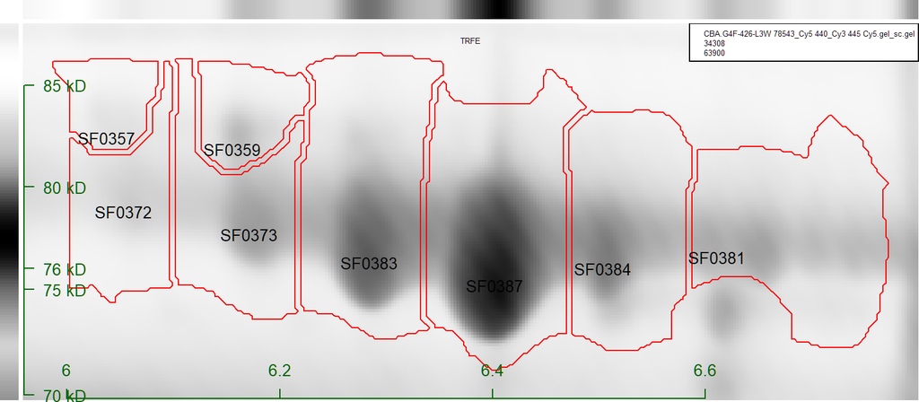

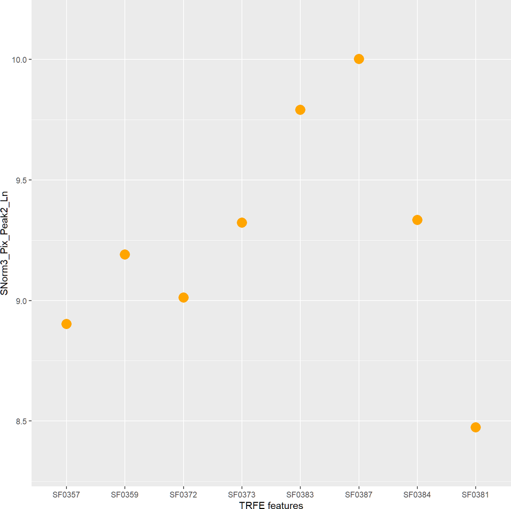

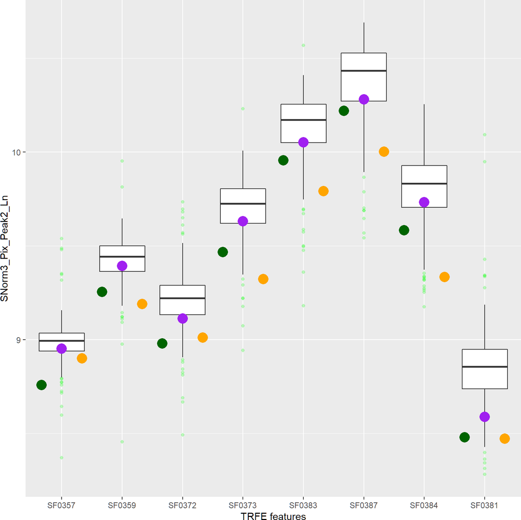

|  | SF0357 | SF0359 | SF0372 | SF0373 | SF0383 | SF0387 | SF0384 | SF0381 |
| --- | --- | --- | --- | --- | --- | --- | --- | --- |
| 50014_Cy5 450_Cy3 455 Cy5 | 8.758255 | 9.254740 | 8.980550 | 9.466222 | 9.955700 | 10.21983 | 9.583420 | 8.479699 |
| 72288_Cy5 440_Cy3 455 Cy5 | 8.951699 | 9.392995 | 9.112507 | 9.631548 | 10.051131 | 10.28042 | 9.731512 | 8.589328 |
| 78543_Cy5 440_Cy3 445 Cy5 | 8.901775 | 9.190750 | 9.012377 | 9.322508 | 9.790879 | 10.00170 | 9.334150 | 8.472823 |

# Alpha-1-antitrypsin (P01009)

[From: Human plasma protein N-glycosylation](https://link.springer.com/article/10.1007/s10719-015-9626-2#Sec4)

> Alpha-1-antitrypsin (AAT), also known as alpha-1-protease inhibitor, alpha-1-antiproteinase or serpin A1, consists of 418 amino acids (including a 24 amino acid signal peptide) with an apparent mass of 51 kDa (including glycosylation). It is mainly produced in the liver by hepatocytes, but is also synthesized in monocytes, intestinal epithelial cells, and in the cornea [52, 208–211]. Due to its small size and polar properties, the glycoprotein can easily move into tissue fluids [52]. In healthy individuals, a plasma level of approximately 1.1 mg/mL is found, but the concentration can increase three- to four-fold during inflammation [212–215]. AAT occurs as three different amino acid sequences, of which the first is set as the standard sequence. Form 2 differs in the amino acid sequence 356–418 and form 3 lacks the amino acid sequence 307–418.

### CBA.G4F-426-L3W A1AT_1

**Replicate 1 : 50014_Cy5 450_Cy3 455 Cy5.gel_sc.gel**

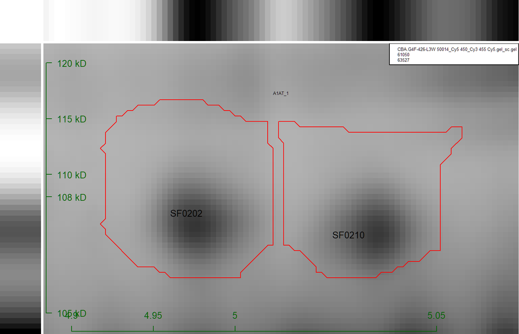

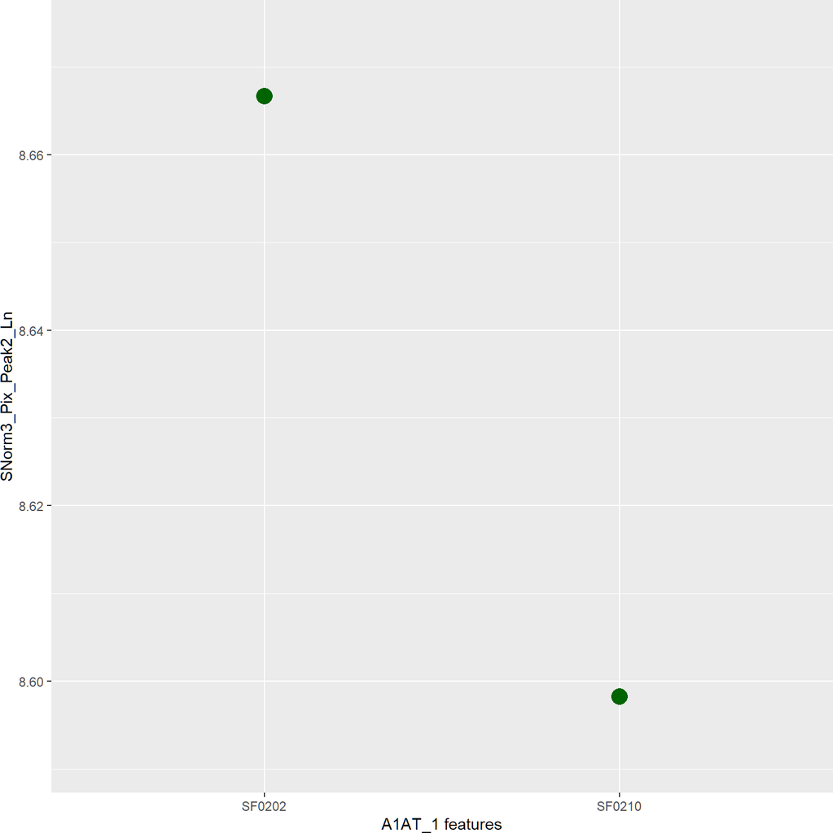

**Replicate 2 : 72288_Cy5 440_Cy3 455 Cy5.gel_sc.gel**

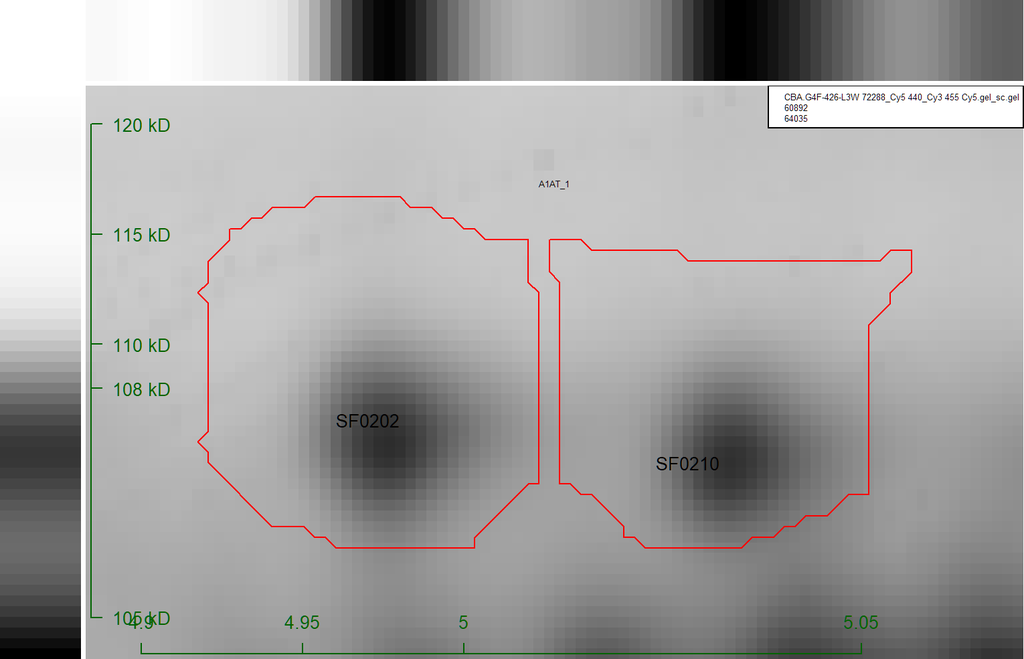

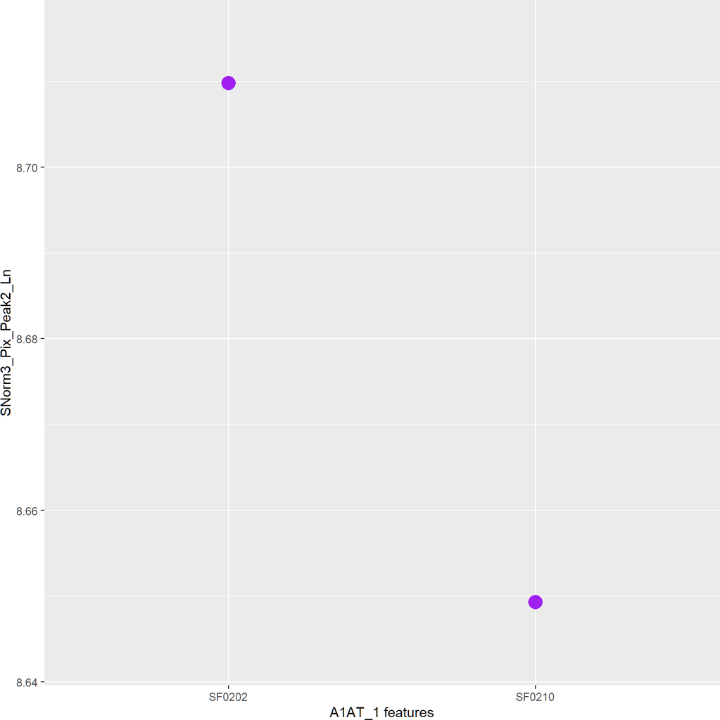

**Replicate 3 : 78543_Cy5 440_Cy3 445 Cy5.gel_sc.gel**

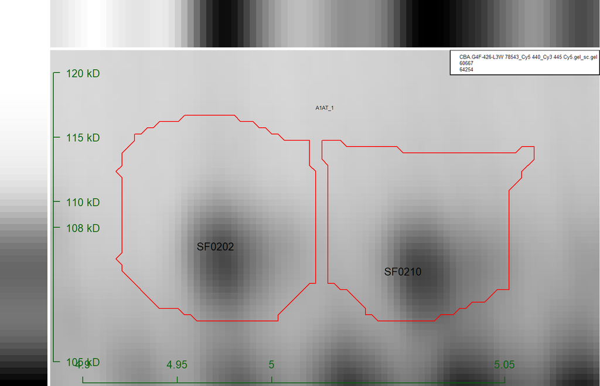

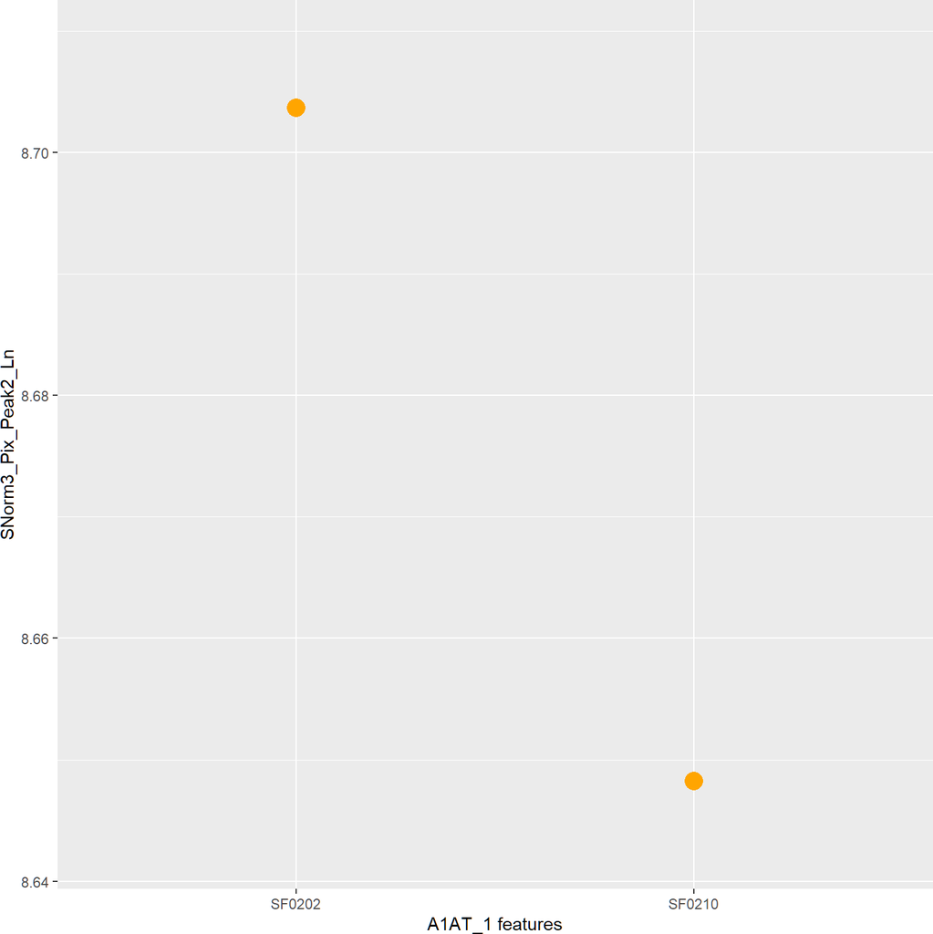

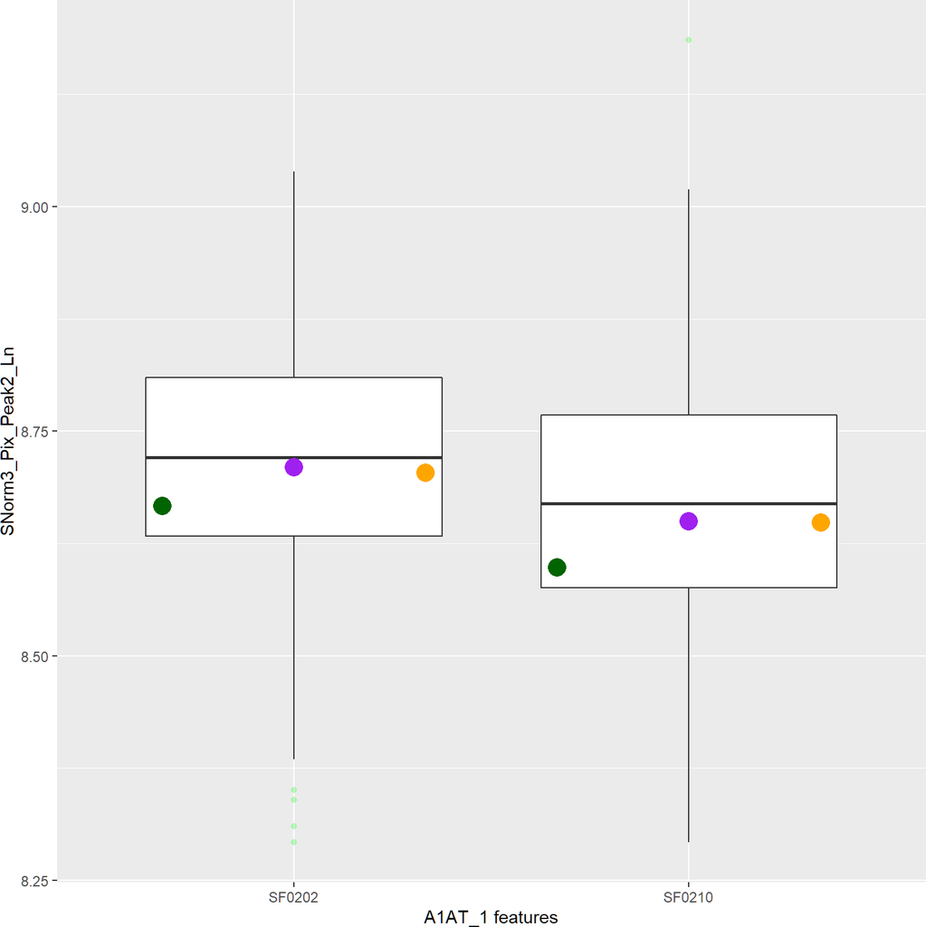

|  | SF0202 | SF0210 |
| --- | --- | --- |
| 50014_Cy5 450_Cy3 455 Cy5 | 8.666647 | 8.598220 |
| 72288_Cy5 440_Cy3 455 Cy5 | 8.709795 | 8.649273 |
| 78543_Cy5 440_Cy3 445 Cy5 | 8.703673 | 8.648222 |

### CBA.G4F-426-L3W A1AT_2

**Replicate 1 : 50014_Cy5 450_Cy3 455 Cy5.gel_sc.gel**

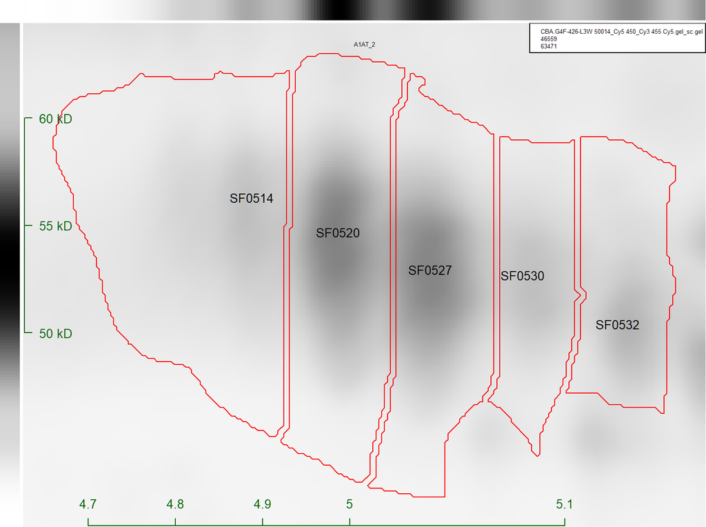

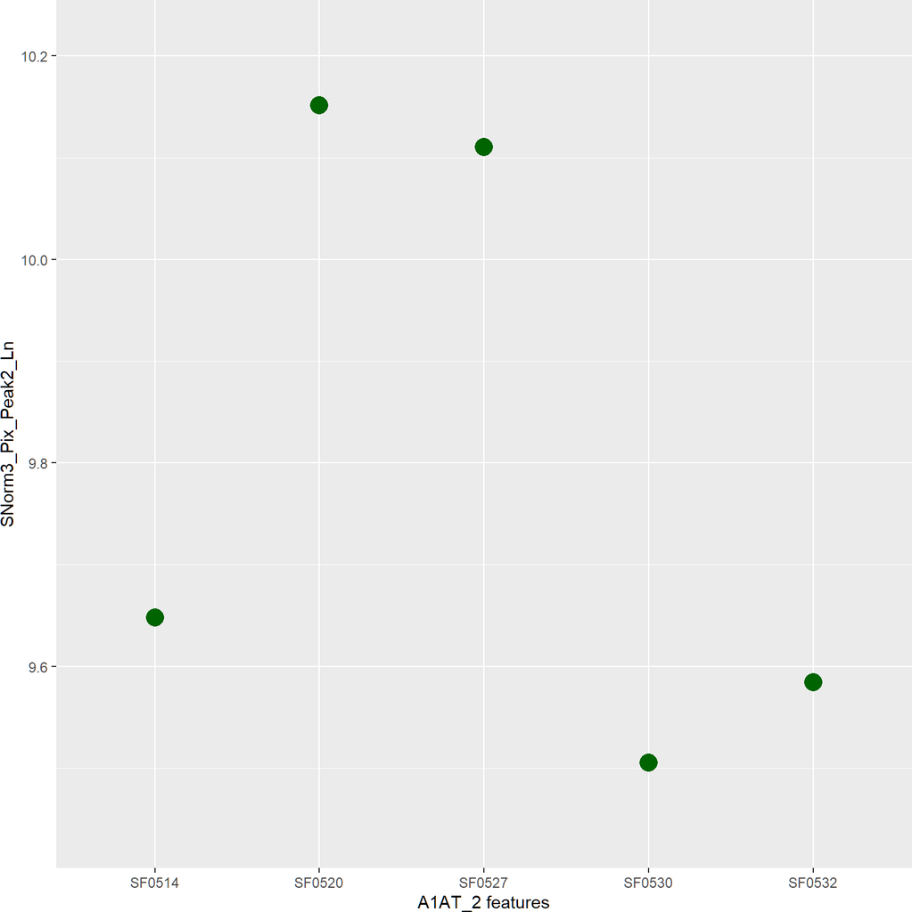

**Replicate 2 : 72288_Cy5 440_Cy3 455 Cy5.gel_sc.gel**

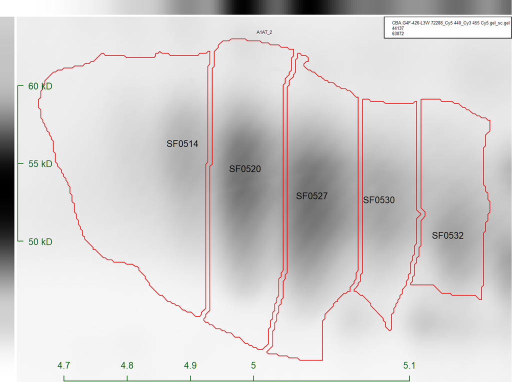

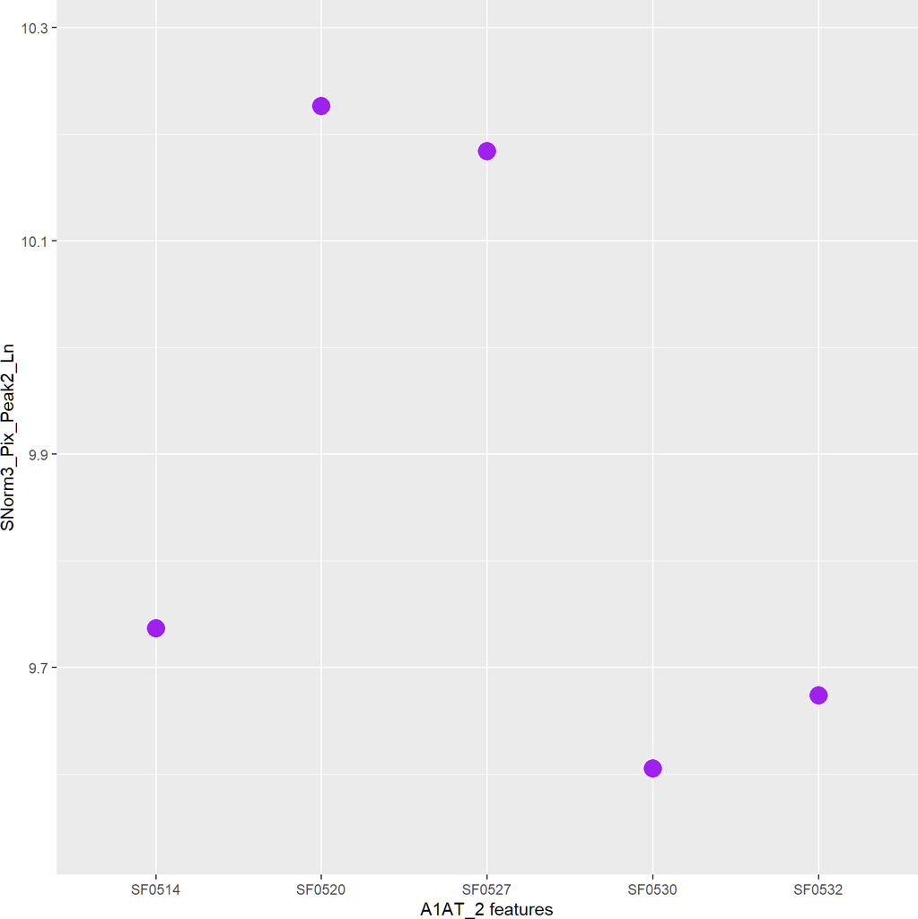

**Replicate 3 : 78543_Cy5 440_Cy3 445 Cy5.gel_sc.gel**

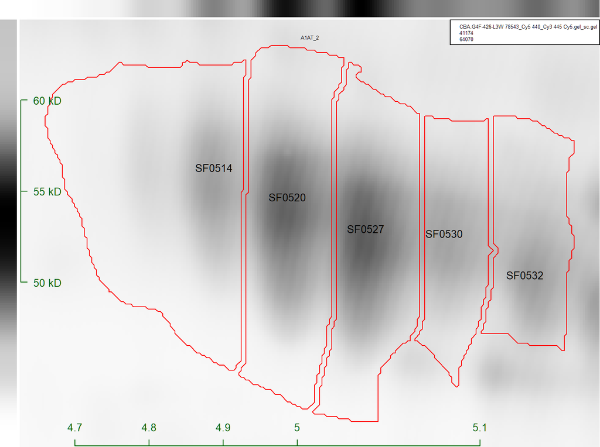

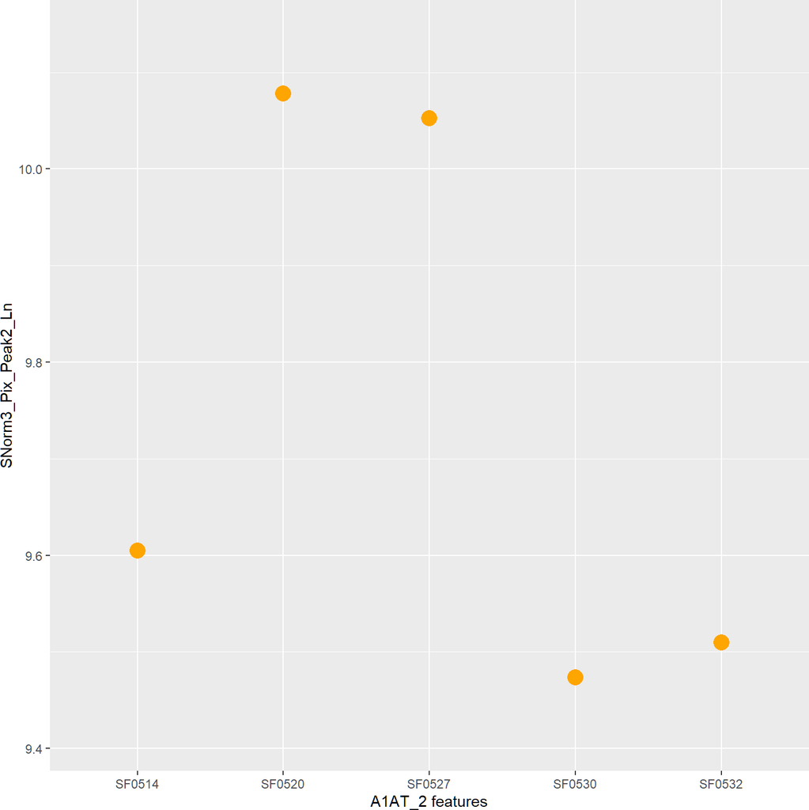

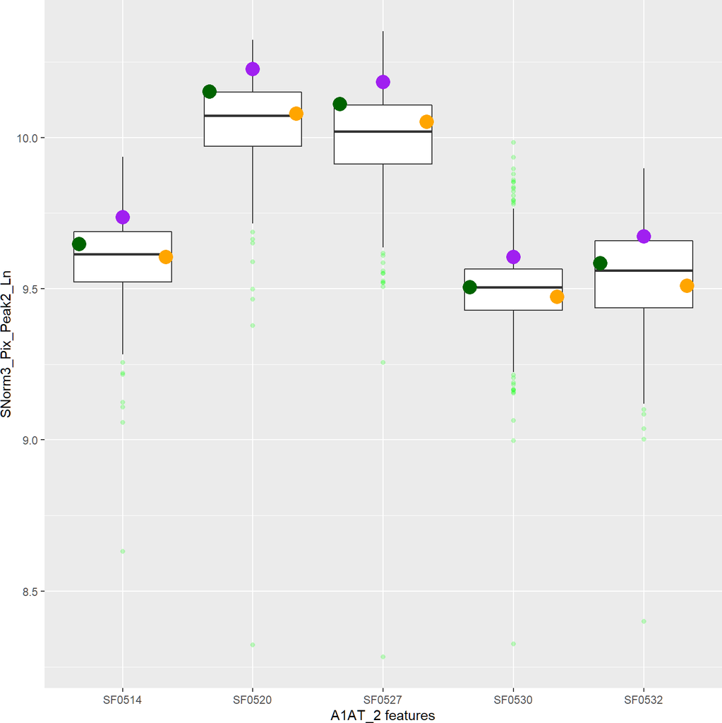

|  | SF0514 | SF0520 | SF0527 | SF0530 | SF0532 |
| --- | --- | --- | --- | --- | --- |
| 50014_Cy5 450_Cy3 455 Cy5 | 9.647821 | 10.15144 | 10.11026 | 9.504948 | 9.584590 |
| 72288_Cy5 440_Cy3 455 Cy5 | 9.736252 | 10.22630 | 10.18388 | 9.604677 | 9.673697 |
| 78543_Cy5 440_Cy3 445 Cy5 | 9.605014 | 10.07807 | 10.05247 | 9.473243 | 9.509407 |

### CBA.G4F-426-L3W A1AT_3

**Replicate 1 : 50014_Cy5 450_Cy3 455 Cy5.gel_sc.gel**

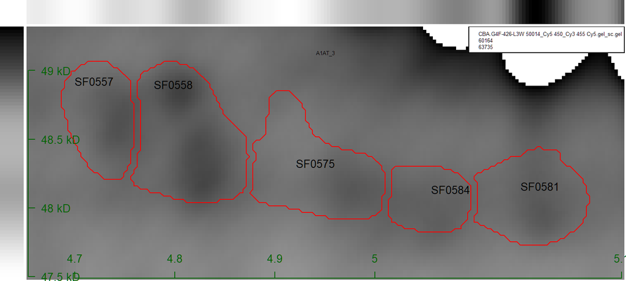

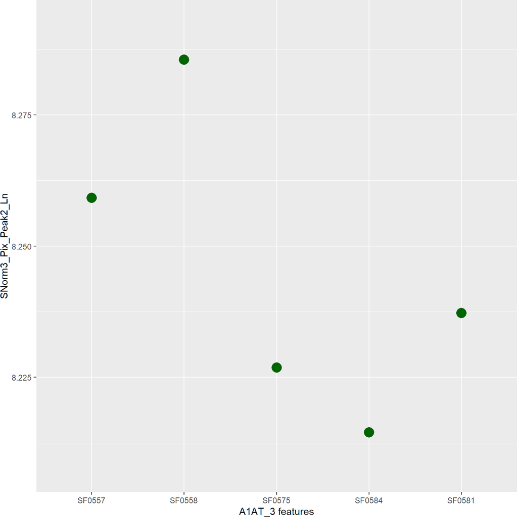

**Replicate 2 : 72288_Cy5 440_Cy3 455 Cy5.gel_sc.gel**

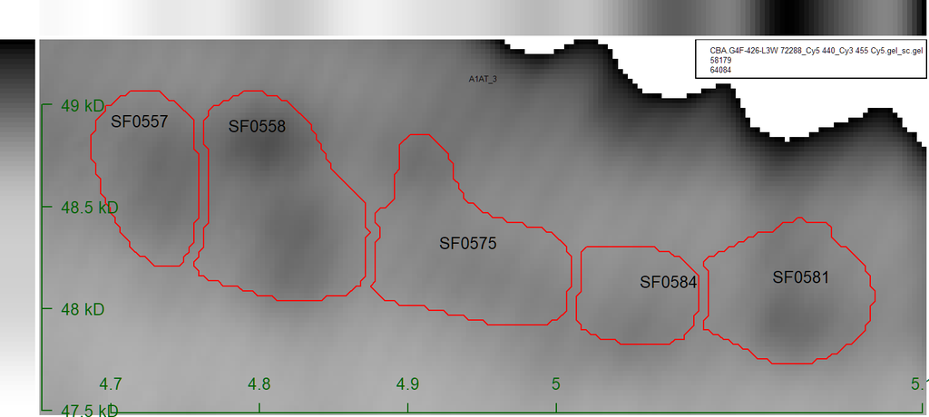

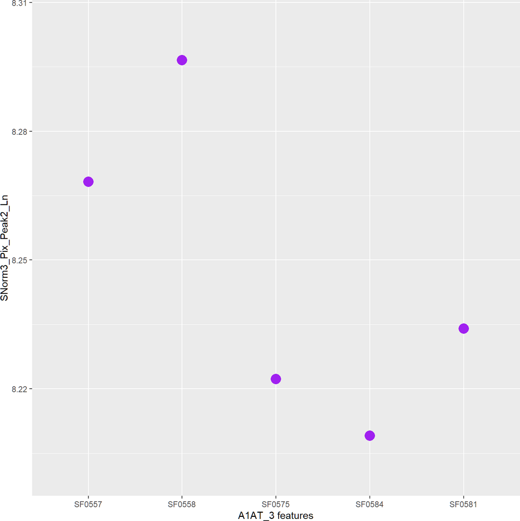

**Replicate 3 : 78543_Cy5 440_Cy3 445 Cy5.gel_sc.gel**

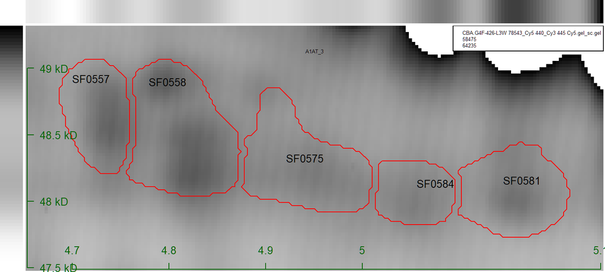

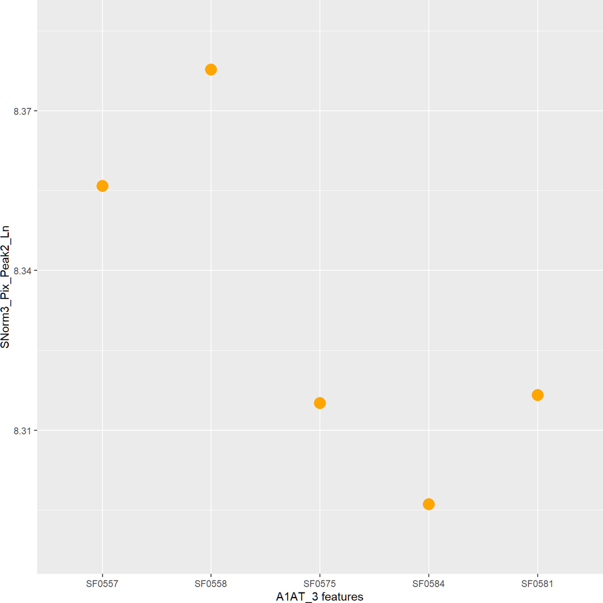

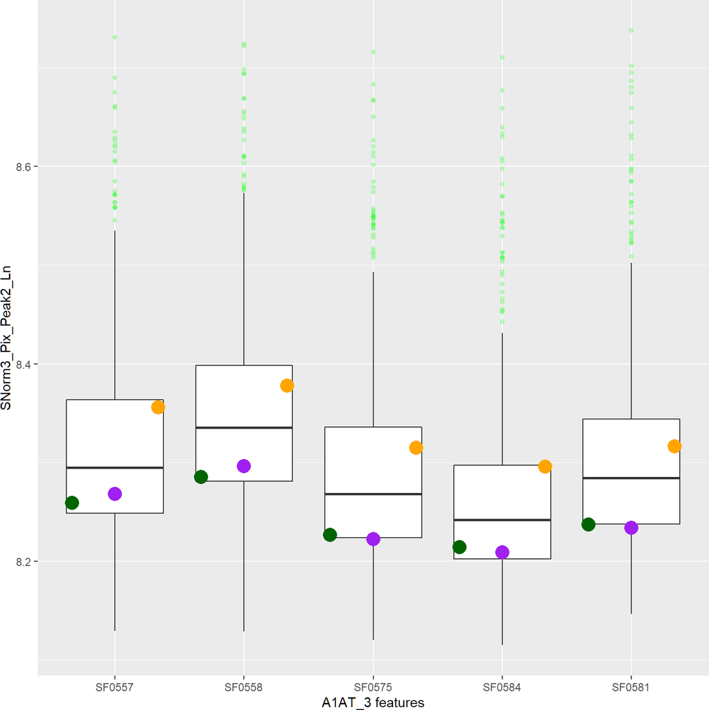

|  | SF0557 | SF0558 | SF0575 | SF0584 | SF0581 |
| --- | --- | --- | --- | --- | --- |
| 50014_Cy5 450_Cy3 455 Cy5 | 8.259199 | 8.285513 | 8.226841 | 8.214465 | 8.237215 |
| 72288_Cy5 440_Cy3 455 Cy5 | 8.268219 | 8.296546 | 8.222285 | 8.209036 | 8.234034 |
| 78543_Cy5 440_Cy3 445 Cy5 | 8.355850 | 8.377701 | 8.315077 | 8.296048 | 8.316545 |

# **Statistical Process Control**

[From: An introduction to statistical process control in research proteomics](https://pubmed.ncbi.nlm.nih.gov/23791708/)

> **Background:** Statistical process control is a well-established and respected method which provides a general purpose, and consistent framework for monitoring and improving the quality of a process. It is routinely used in many industries where the quality of final products is critical and is often required in clinical diagnostic laboratories [1,2]. To date, the methodology has been little utilised in research proteomics. It has been shown to be capable of delivering quantitative QC procedures for qualitative clinical assays [3] making it an ideal methodology to apply to this area of biological research.

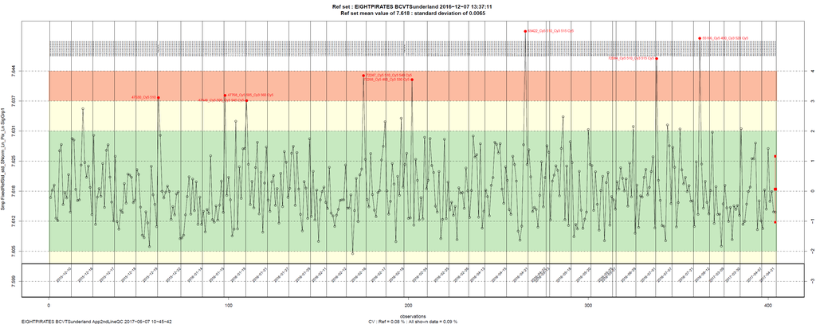

# **Audit Logs:**

Run overview

| Run # | 208 |
| --- | --- |
| Sample / Study | Human plasma (Lot: SLCC1673)/ NUBZ64100, NUCX182416, NUBZ648698, NUAQ387360, NUFH402412, NUFT865086, NUFR670624, NUFT766262, NUFU715690, NUFT770122, NUFT766280, NUCX210223 |
| Completion (Scan) Date | 25/09/2020 |
| Comments | OOD GE strips, biotium dye, sample load 2uL. Pre-mix buffers. Standard IEF with cuploading. Standard 2D with type 2 water. 4% equilibration buffer. |

# Labelling

**Technician**:EA & NH

**Sample:** 2µL Human Plasma

| Solution / reagent | Batch / Lot # | Reference |
| --- | --- | --- |
| DIGE labelling buffer | 6 | LB-RS-06 |
| Tris-HCl pH 8.5 | 2 | LB-RS-02 |
| DMF | STBH7014 |  |
| Cy3 (Biotium) | 13C1212 |  |
| Cy5 (Biotium) | 18C0626-1075 |  |
| Lysine | 4 | LB-RS-07 |
| 2x DIGE buffer | 6 | LB-RS-04 |

# Iso Electric Focusing

**Technician**:EA & NH

| Solution / reagent | Batch / Lot # |
| --- | --- |
| 1x DIGE buffer | 14 |
| Control sample | Human plasma/ SLCC1673 |
| IPG strips | 10277023 |
| Reswell Date | 22/09/2020 |
| Time strip 1 | 16:10:00 |
| Time oil added | 16:40:00 |

| Equipment | ID # |
| --- | --- |
| Reswell tray | 3 |
| IPGphor unit | 1 |

##### Transfer to IPGphor: 23/09/2020 10:54:00

**Technician**: EA & NH

[output not shown]

# 2D SDS

##### Casting (A2DE optimiser)

**Technician**: NH

| Solution / reagent | Batch / Lot # | Weight (g) | Reference |
| --- | --- | --- | --- |
| Tris-SDS | 24 |  | LB-RS-11 |
| Glycerol | 17 |  | LB-RS-09 |
| Acrylamide | 07-19-22 |  | WI-LB-001 5.2.1(1) |
| APS | MKCG5404 |  | WI-LB-001 5.2.1(3a) |
| TEMED | STBH7073 |  | WI-LB-001 5.2.1(3b) |

| Equipment | Set |
| --- | --- |
| Gel plates: | 1 |
| Casting box: | 1 |
| Optimiser: | 1 |

##### Second dimension run properties (2D Tank1)

**Technician**: EA & NH

| Event | Time | W | mA | V |
| --- | --- | --- | --- | --- |
| Start | 15:32:00 | 8 | 170 | 46 |
| Duration | 17h30 |  |  |  |
| Power up | 09:02:00 |  |  |  |
| Time off | 09:18:00 | 25 | 190 | 130 |
| Total time | 17h 46m |  |  |  |

# Imaging

**Technician**: EA & NH

**Imager:** Typhoon 9400

**Calibration App Log File**

The imager was calibrated on 25/09/2020 following protocol P-212 and Calibration App Version 1.01.

[output not shown]

**Scanner Driver App**

The gels were imaged in pairs using Scanner Driver App version 1.01. The app automatically cropped and rotated the scans. Scans were performed at 100 and 200 micron resolutions. Cy3 and Cy5 channels were imaged simultaneously.

**Whole gel visual review**

The gels passed a visual review (under OP-28) before upload to the cloud for processing.

**Scanning App Log File**

> Opening excel file: A:\Lab\GelRunning\Runs\0208\Run 208.xlsx

> Loaded scans:

> Strip1: 49844 Strip2: 49845

> Strip1: 49846 Strip2: 49847

> Strip1: 49848 Strip2: 49849

> Strip1: 49850 Strip2: 49851

> Strip1: 49852 Strip2: 49853

> Strip1: 49854 Strip2: 49855

> Starting scan of Strip1: 49844 Strip2: 49845

> Finished scan of Strip1: 49844 Strip2: 49845

> Scanned images in 00:31:26.9429270:

> c:\Biosignatures data\2020-09-25-Run 208\9400\200\49844_Cy5 500_Cy3 530 Cy3.gel

> c:\Biosignatures data\2020-09-25-Run 208\9400\200\49844_Cy5 500_Cy3 530 Cy5.gel

> c:\Biosignatures data\2020-09-25-Run 208\9400\200\49845_Cy5 500_Cy3 530 Cy3.gel

> c:\Biosignatures data\2020-09-25-Run 208\9400\200\49845_Cy5 500_Cy3 530 Cy5.gel

> c:\Biosignatures data\2020-09-25-Run 208\9400\49844_Cy5 560_Cy3 590 Cy3.gel

> c:\Biosignatures data\2020-09-25-Run 208\9400\49844_Cy5 560_Cy3 590 Cy5.gel

> c:\Biosignatures data\2020-09-25-Run 208\9400\49845_Cy5 560_Cy3 590 Cy3.gel

> c:\Biosignatures data\2020-09-25-Run 208\9400\49845_Cy5 560_Cy3 590 Cy5.gel

> File 49844_Cy5 560_Cy3 590 Cy3.gel had 77362 saturated pixels of 5304000

> File 49845_Cy5 560_Cy3 590 Cy3.gel had 107383 saturated pixels of 5304000

> Starting scan of Strip1: 49846 Strip2: 49847

> Finished scan of Strip1: 49846 Strip2: 49847

> Scanned images in 00:31:16.6743397:

> c:\Biosignatures data\2020-09-25-Run 208\9400\200\49846_Cy5 500_Cy3 530 Cy3.gel

> c:\Biosignatures data\2020-09-25-Run 208\9400\200\49846_Cy5 500_Cy3 530 Cy5.gel

> c:\Biosignatures data\2020-09-25-Run 208\9400\200\49847_Cy5 500_Cy3 530 Cy3.gel

> c:\Biosignatures data\2020-09-25-Run 208\9400\200\49847_Cy5 500_Cy3 530 Cy5.gel

> c:\Biosignatures data\2020-09-25-Run 208\9400\49846_Cy5 560_Cy3 590 Cy3.gel

> c:\Biosignatures data\2020-09-25-Run 208\9400\49846_Cy5 560_Cy3 590 Cy5.gel

> c:\Biosignatures data\2020-09-25-Run 208\9400\49847_Cy5 560_Cy3 590 Cy3.gel

> c:\Biosignatures data\2020-09-25-Run 208\9400\49847_Cy5 560_Cy3 590 Cy5.gel

> File 49846_Cy5 560_Cy3 590 Cy3.gel had 99403 saturated pixels of 5304000

> File 49847_Cy5 560_Cy3 590 Cy3.gel had 85804 saturated pixels of 5304000

> Starting scan of Strip1: 49848 Strip2: 49849

> Finished scan of Strip1: 49848 Strip2: 49849

> Scanned images in 00:31:19.2494869:

> c:\Biosignatures data\2020-09-25-Run 208\9400\200\49848_Cy5 500_Cy3 530 Cy3.gel

> c:\Biosignatures data\2020-09-25-Run 208\9400\200\49848_Cy5 500_Cy3 530 Cy5.gel

> c:\Biosignatures data\2020-09-25-Run 208\9400\200\49849_Cy5 500_Cy3 530 Cy3.gel

> c:\Biosignatures data\2020-09-25-Run 208\9400\200\49849_Cy5 500_Cy3 530 Cy5.gel

> c:\Biosignatures data\2020-09-25-Run 208\9400\49848_Cy5 560_Cy3 590 Cy3.gel

> c:\Biosignatures data\2020-09-25-Run 208\9400\49848_Cy5 560_Cy3 590 Cy5.gel

> c:\Biosignatures data\2020-09-25-Run 208\9400\49849_Cy5 560_Cy3 590 Cy3.gel

> c:\Biosignatures data\2020-09-25-Run 208\9400\49849_Cy5 560_Cy3 590 Cy5.gel

> File 49848_Cy5 560_Cy3 590 Cy3.gel had 97777 saturated pixels of 5304000

> File 49849_Cy5 560_Cy3 590 Cy3.gel had 61913 saturated pixels of 5304000

> Starting scan of Strip1: 49850 Strip2: 49851

> Finished scan of Strip1: 49850 Strip2: 49851

> Scanned images in 00:31:20.2025415:

> c:\Biosignatures data\2020-09-25-Run 208\9400\200\49850_Cy5 500_Cy3 530 Cy3.gel

> c:\Biosignatures data\2020-09-25-Run 208\9400\200\49850_Cy5 500_Cy3 530 Cy5.gel

> c:\Biosignatures data\2020-09-25-Run 208\9400\200\49851_Cy5 500_Cy3 530 Cy3.gel

> c:\Biosignatures data\2020-09-25-Run 208\9400\200\49851_Cy5 500_Cy3 530 Cy5.gel

> c:\Biosignatures data\2020-09-25-Run 208\9400\49850_Cy5 560_Cy3 590 Cy3.gel

> c:\Biosignatures data\2020-09-25-Run 208\9400\49850_Cy5 560_Cy3 590 Cy5.gel

> c:\Biosignatures data\2020-09-25-Run 208\9400\49851_Cy5 560_Cy3 590 Cy3.gel

> c:\Biosignatures data\2020-09-25-Run 208\9400\49851_Cy5 560_Cy3 590 Cy5.gel

> File 49850_Cy5 560_Cy3 590 Cy3.gel had 97818 saturated pixels of 5304000

> File 49851_Cy5 560_Cy3 590 Cy3.gel had 69973 saturated pixels of 5304000

> Starting scan of Strip1: 49852 Strip2: 49853

> Finished scan of Strip1: 49852 Strip2: 49853

> Scanned images in 00:31:18.1004212:

> c:\Biosignatures data\2020-09-25-Run 208\9400\200\49852_Cy5 500_Cy3 530 Cy3.gel

> c:\Biosignatures data\2020-09-25-Run 208\9400\200\49852_Cy5 500_Cy3 530 Cy5.gel

> c:\Biosignatures data\2020-09-25-Run 208\9400\200\49853_Cy5 500_Cy3 530 Cy3.gel

> c:\Biosignatures data\2020-09-25-Run 208\9400\200\49853_Cy5 500_Cy3 530 Cy5.gel

> c:\Biosignatures data\2020-09-25-Run 208\9400\49852_Cy5 560_Cy3 590 Cy3.gel

> c:\Biosignatures data\2020-09-25-Run 208\9400\49852_Cy5 560_Cy3 590 Cy5.gel

> c:\Biosignatures data\2020-09-25-Run 208\9400\49853_Cy5 560_Cy3 590 Cy3.gel

> c:\Biosignatures data\2020-09-25-Run 208\9400\49853_Cy5 560_Cy3 590 Cy5.gel

> File 49852_Cy5 560_Cy3 590 Cy3.gel had 81429 saturated pixels of 5304000

> File 49853_Cy5 560_Cy3 590 Cy3.gel had 82430 saturated pixels of 5304000

> Starting scan of Strip1: 49854 Strip2: 49855

> Finished scan of Strip1: 49854 Strip2: 49855

> Scanned images in 00:31:19.8435209:

> c:\Biosignatures data\2020-09-25-Run 208\9400\200\49854_Cy5 500_Cy3 530 Cy3.gel

> c:\Biosignatures data\2020-09-25-Run 208\9400\200\49854_Cy5 500_Cy3 530 Cy5.gel

> c:\Biosignatures data\2020-09-25-Run 208\9400\200\49855_Cy5 500_Cy3 530 Cy3.gel

> c:\Biosignatures data\2020-09-25-Run 208\9400\200\49855_Cy5 500_Cy3 530 Cy5.gel

> c:\Biosignatures data\2020-09-25-Run 208\9400\49854_Cy5 560_Cy3 590 Cy3.gel

> c:\Biosignatures data\2020-09-25-Run 208\9400\49854_Cy5 560_Cy3 590 Cy5.gel

> c:\Biosignatures data\2020-09-25-Run 208\9400\49855_Cy5 560_Cy3 590 Cy3.gel

> c:\Biosignatures data\2020-09-25-Run 208\9400\49855_Cy5 560_Cy3 590 Cy5.gel

> File 49854_Cy5 560_Cy3 590 Cy3.gel had 89075 saturated pixels of 5304000

> File 49855_Cy5 560_Cy3 590 Cy3.gel had 71489 saturated pixels of 5304000